# AED Conceitos - Aula 1

Fabrício Venturim

2023-04-25

```r
if(!require(utf8)) install.packages("utf8")
library(utf8)
Sys.setlocale("LC_ALL", "pt_br.utf-8")
```

```
## [1] "LC_COLLATE=pt_br.utf-8;LC_CTYPE=pt_br.utf-8;LC_MONETARY=pt_br.utf-8;LC_NUMERIC=C;LC_TIME=pt_br.utf-8"
```

# 1 Análise Exploratória de Dados

Aprenderemos como usar a visualização e a transformação para explorar seus dados de maneira sistemática.

A Análise Exploratória de Dados (AED) é uma das etapas fundamentais no processo de análise de dados. Ela tem como objetivo compreender os dados disponíveis, identificar padrões, tendências, valores extremos e outras características importantes dos dados. A AED pode ser realizada por meio de **visualizações**, **estatísticas descritivas** e outras técnicas exploratórias.

O R é uma linguagem de programação muito utilizada em análise de dados e possui diversas bibliotecas e ferramentas que facilitam a realização da AED. Uma das bibliotecas mais populares é o tidyverse, que contém uma série de pacotes que permitem a manipulação, visualização e modelagem de dados.

Neste documento, iremos explorar algumas técnicas de AED utilizando o R e o tidyverse. Iremos aprender como carregar dados em R, manipulá-los e visualizá-los para obter insights valiosos sobre o conjunto de dados. Além disso, iremos explorar técnicas de limpeza e pré-processamento de dados para garantir que os dados estejam prontos para serem utilizados em análises mais avançadas.

> “Far better an approximate answer to the right question, which is often vague, than an exact answer to the wrong question, which can always be made precise.” — **John Tukey**

Seu objetivo durante a EDA é desenvolver uma compreensão de seus dados. A maneira mais fácil de fazer isso é usar perguntas como ferramentas para orientar sua investigação. Quando você faz uma pergunta, ela concentra sua atenção em uma parte específica do seu conjunto de dados e ajuda a decidir quais gráficos, modelos ou transformações fazer.

**Uma postura crucial é compreender os conceitos fundamentais da AED, uma vez que, tendo uma compreensão clara da teoria e do processo de análise, a escolha da linguagem de programação torna-se menos relevante. Isso significa que os conceitos abordados são aplicáveis não apenas ao R, mas a outras linguagens também.**

## 1.1 Componentes da AED

Existem componentes principais na exploração de dados:

1. Entender suas variáveis
2. Limpar seu conjunto de dados (Próxima aula)
3. Analisar relações entre variáveis

## 1.2 Pré-requisitos

Vamos importar a biblioteca do `tidyverse`.

```r
if(!require(tidyverse)) install.packages("tidyverse")
library(tidyverse)
```

## 1.3 O conjunto de dados `milsa`

O livro “Estatística Básica” de W. O. Bussab e P. A. Morettin traz no segundo capítulo um conjunto de dados hipotético de atributos de 36 funcionários da companhia “Milsa”. Os dados estão reproduzidos na tabela abaixo. Consulte o livro para mais detalhes sobre este dados.

Ler o csv `Tabela1.csv`:

```r
milsa = read.csv("data/Tabela1.csv")
```

```r
milsa
```

```
##     N Estado.Civil  Grau.de.Instrução N.de.Filhos Salario..x.Sal.Min. Anos
## 1   1     solteiro ensino fundamental           2                4.00   26
## 2   2       casado ensino fundamental           1                4.56   32
## 3   3       casado ensino fundamental           2                5.25   36
## 4   4     solteiro       ensino médio           1                5.73   20
## 5   5     solteiro ensino fundamental           0                6.26   40
## 6   6       casado ensino fundamental           0                6.66   28
## 7   7     solteiro ensino fundamental           1                6.86   41
## 8   8     solteiro ensino fundamental           2                7.39   43
## 9   9       casado       ensino médio           1                7.59   34
## 10 10     solteiro       ensino médio           4                7.44   23
## 11 11       casado       ensino médio           2                8.12   33
## 12 12     solteiro ensino fundamental           0                8.46   27
## 13 13     solteiro       ensino médio           0                8.74   37
## 14 14       casado ensino fundamental           3                8.95   44
```

[output cut: 59 more lines]

```r
head(milsa)
```

```
##   N Estado.Civil  Grau.de.Instrução N.de.Filhos Salario..x.Sal.Min. Anos Meses
## 1 1     solteiro ensino fundamental           2                4.00   26     3
## 2 2       casado ensino fundamental           1                4.56   32    10
## 3 3       casado ensino fundamental           2                5.25   36     5
## 4 4     solteiro       ensino médio           1                5.73   20    10
## 5 5     solteiro ensino fundamental           0                6.26   40     7
## 6 6       casado ensino fundamental           0                6.66   28     0
##   Região.de.Procedência  X
## 1              interior NA
## 2               capital NA
## 3               capital NA
## 4                 outra NA
## 5                 outra NA
## 6              interior NA
```

## 1.4 Estrutura do Dataframe

### 1.4.1 Adicionar Colunas no Dataframe

Podemos definir uma nova variável (coluna), por exemplo, chamada `Idade`, a partir das variáveis `Anos` e `Meses`:

```r
milsa$Idade = milsa$Anos + milsa$Meses/12
```

```r
milsa
```

```
##     N Estado.Civil  Grau.de.Instrução N.de.Filhos Salario..x.Sal.Min. Anos
## 1   1     solteiro ensino fundamental           2                4.00   26
## 2   2       casado ensino fundamental           1                4.56   32
## 3   3       casado ensino fundamental           2                5.25   36
## 4   4     solteiro       ensino médio           1                5.73   20
## 5   5     solteiro ensino fundamental           0                6.26   40
## 6   6       casado ensino fundamental           0                6.66   28
## 7   7     solteiro ensino fundamental           1                6.86   41
## 8   8     solteiro ensino fundamental           2                7.39   43
## 9   9       casado       ensino médio           1                7.59   34
## 10 10     solteiro       ensino médio           4                7.44   23
## 11 11       casado       ensino médio           2                8.12   33
## 12 12     solteiro ensino fundamental           0                8.46   27
## 13 13     solteiro       ensino médio           0                8.74   37
## 14 14       casado ensino fundamental           3                8.95   44
```

[output cut: 59 more lines]

- Adicionar coluna: `table$colunaNova`
- Atualizar coluna: `table$colunaAtualizar`

## 1.5 Excluir Coluna

Também podemos excluir coluna do nosso dataframe:

```r
milsa = subset(milsa, select = -X)
```

Se quiser apagar mais de uma coluna, utilize: `milsa <- subset(milsa, select = -c(Meses, Ano))`.

## 1.6 Mudar Nome de colunas

Para ver os nomes das colunas do nosso dataframe, podemos utilizar a função `names()`.

```r
names(milsa)
```

```
## [1] "N"                     "Estado.Civil"          "Grau.de.Instrução"
## [4] "N.de.Filhos"           "Salario..x.Sal.Min."   "Anos"
## [7] "Meses"                 "Região.de.Procedência" "Idade"
```

Alguns nomes estão escritos de forma estranha e pode facilitar futuras análises alterar o nome delas. Podemos alterar o nome das colunas usando um filtro no `names`:

```r
names(milsa)[names(milsa) == "Salario..x.Sal.Min."] = "Salario"
names(milsa)[names(milsa) == "N.de.Filhos"] = "Filhos"
names(milsa)[names(milsa) == "Grau.de.Instrução"] = "Grau_Instrucao"
names(milsa)[names(milsa) == "Região.de.Procedência"] = "Regiao_Procedencia"
names(milsa)[names(milsa) == "Estado.Civil"] = "Estado_Civil"
```

```r
milsa
```

```
##     N Estado_Civil     Grau_Instrucao Filhos Salario Anos Meses
## 1   1     solteiro ensino fundamental      2    4.00   26     3
## 2   2       casado ensino fundamental      1    4.56   32    10
## 3   3       casado ensino fundamental      2    5.25   36     5
## 4   4     solteiro       ensino médio      1    5.73   20    10
## 5   5     solteiro ensino fundamental      0    6.26   40     7
## 6   6       casado ensino fundamental      0    6.66   28     0
## 7   7     solteiro ensino fundamental      1    6.86   41     0
## 8   8     solteiro ensino fundamental      2    7.39   43     4
## 9   9       casado       ensino médio      1    7.59   34    10
## 10 10     solteiro       ensino médio      4    7.44   23     6
## 11 11       casado       ensino médio      2    8.12   33     6
## 12 12     solteiro ensino fundamental      0    8.46   27    11
## 13 13     solteiro       ensino médio      0    8.74   37     5
## 14 14       casado ensino fundamental      3    8.95   44     2
```

[output cut: 59 more lines]

# 2 Análise Univariada

A análise univariada consiste basicamente em, para cada uma das variáveis individualmente:

- Classificar a variável quanto a seu tipo: qualitativa (nominal ou ordinal) ou quantitativa (discreta ou contínua).
- Obter tabelas, gráficos e/ou medidas que resumam a variável.

A partir destes resultados pode-se montar um resumo geral dos dados.

A seguir vamos mostrar como obter tabelas, gráficos e medidas com o R.

## 2.1 Compreenção das suas variáveis

Uma boa forma de iniciar uma análise exploratória adequada é verificar os tipos de variáveis disponíveis. Variáveis podem ser classificadas da seguinte forma:

- Qualitativas
  - Nominais
  - Ordinais
- Quantitativas
  - Discretas
  - Contínuas

e podem ser resumidas por tabelas, gráficos e/ou medidas.

### 2.1.1 Arrumando a Estrutura do dataframe

A função `str()` em R é uma função útil para examinar a estrutura de um objeto e exibir informações sobre seu conteúdo. “str” significa “structure” em inglês.

Quando você aplica a função `str()` a um objeto em R, a função retorna informações sobre o tipo de objeto, seu comprimento, dimensões (se for uma matriz, array ou dataframe), nomes de coluna ou linha (se aplicável), e uma prévia do conteúdo do objeto. A saída fornecida pela função str() pode ajudar a entender melhor a estrutura dos dados e como eles estão organizados.

```r
str(milsa)
```

```
## 'data.frame':    36 obs. of  9 variables:
##  $ N                 : int  1 2 3 4 5 6 7 8 9 10 ...
##  $ Estado_Civil      : chr  "solteiro" "casado" "casado" "solteiro" ...
##  $ Grau_Instrucao    : chr  "ensino fundamental" "ensino fundamental" "ensino fundamental" "ensino médio" ...
##  $ Filhos            : int  2 1 2 1 0 0 1 2 1 4 ...
##  $ Salario           : num  4 4.56 5.25 5.73 6.26 6.66 6.86 7.39 7.59 7.44 ...
##  $ Anos              : int  26 32 36 20 40 28 41 43 34 23 ...
##  $ Meses             : int  3 10 5 10 7 0 0 4 10 6 ...
##  $ Regiao_Procedencia: chr  "interior" "capital" "capital" "outra" ...
##  $ Idade             : num  26.2 32.8 36.4 20.8 40.6 ...
```

Podemos classificar todas as variáveis desse conjunto de dados como:

- **Funcionario**: Quantitativa discreta
- **Estado.Civil**: Qualitativa nominal
- **Grau.de.Instrucao**: Qualitativa ordinal
- **Filhos**: Quantitativa discreta
- **Salario**: Quantitativa contínua
- **Anos**: Quantitativa discreta
- **Meses**: Quantitativa discreta
- **Regiao.de.Procedencia**: Qualitativa nominal

No R, temos que cada tipo de variável é representada por:

- **Quantitativa contínua**: `num`
- **Quantitativa discreta**: `int`
- **Qualitativa nominal**: `factor`
- **Qualitativa ordinal**: `ordered factor`

A correta especificação do tipo das variáveis em R é fundamental para realizar uma análise exploratória de dados precisa e completa.

Ao importar dados em R, por exemplo, é importante verificar se as variáveis foram importadas com o tipo correto (por exemplo, como numéricas ou como fatores). Se as variáveis não estiverem corretamente especificadas, a análise exploratória pode ser prejudicada, pois as estatísticas descritivas, gráficos e outras análises podem não refletir adequadamente as características dos dados.

Por exemplo, é importante trocar uma variável categórica do tipo “character” para “factor” em R por algumas razões:

1. Os fatores têm uma estrutura interna otimizada que facilita a manipulação e análise de dados categóricos em R, em comparação com variáveis do tipo “character”.
2. A transformação da variável “character” em “factor” permite a aplicação de funções específicas de análise de dados categóricos em R, como a função table() para a criação de tabelas de frequência e a função aggregate() para a agregação de dados categóricos por grupos.
3. Quando uma variável categórica é definida como um “factor”, R reconhece imediatamente a natureza categórica da variável e permite que as funções e procedimentos que trabalham com dados categóricos sejam aplicados a essa variável de forma mais eficiente e precisa.
4. A especificação correta do tipo de variável também pode melhorar a legibilidade do código, facilitando a comunicação entre membros da equipe que trabalham com análise de dados.

Em resumo, a transformação de variáveis categóricas do tipo “character” para “factor” em R é importante para facilitar a manipulação, análise e visualização de dados categóricos de maneira mais eficiente e precisa, além de melhorar a legibilidade do código e a comunicação entre membros da equipe.

Olhando novamente para as informações, podemos reparar que algumas não estão corretas:

```r
milsa$Estado_Civil = factor(milsa$Estado_Civil)
milsa$Regiao_Procedencia = factor(milsa$Regiao_Procedencia)
milsa$Grau_Instrucao = factor(milsa$Grau_Instrucao, ordered = T)
```

Temos que trocar `Estado.Civil` e `Região.de.Procedência` de `chr` para `factor`e `Grau.de.Instrução` para `ordered factor`:

```r
str(milsa)
```

```
## 'data.frame':    36 obs. of  9 variables:
##  $ N                 : int  1 2 3 4 5 6 7 8 9 10 ...
##  $ Estado_Civil      : Factor w/ 2 levels "casado","solteiro": 2 1 1 2 2 1 2 2 1 2 ...
##  $ Grau_Instrucao    : Ord.factor w/ 3 levels "ensino fundamental"<..: 1 1 1 2 1 1 1 1 2 2 ...
##  $ Filhos            : int  2 1 2 1 0 0 1 2 1 4 ...
##  $ Salario           : num  4 4.56 5.25 5.73 6.26 6.66 6.86 7.39 7.59 7.44 ...
##  $ Anos              : int  26 32 36 20 40 28 41 43 34 23 ...
##  $ Meses             : int  3 10 5 10 7 0 0 4 10 6 ...
##  $ Regiao_Procedencia: Factor w/ 3 levels "capital","interior",..: 2 1 1 3 3 2 2 1 1 3 ...
##  $ Idade             : num  26.2 32.8 36.4 20.8 40.6 ...
```

```r
class(milsa$Grau_Instrucao)
```

```
## [1] "ordered" "factor"
```

Se quiser ver um tipo de uma variável isolada, basta usar `class()`:

```r
class(milsa$Grau_Instrucao)
```

```
## [1] "ordered" "factor"
```

```r
milsa$Grau_Instrucao
```

```
##  [1] ensino fundamental ensino fundamental ensino fundamental ensino médio
##  [5] ensino fundamental ensino fundamental ensino fundamental ensino fundamental
##  [9] ensino médio       ensino médio       ensino médio       ensino fundamental
## [13] ensino médio       ensino fundamental ensino médio       ensino médio
## [17] ensino médio       ensino fundamental superior           ensino médio
## [21] ensino médio       ensino médio       ensino fundamental superior
## [25] ensino médio       ensino médio       ensino fundamental ensino médio
## [29] ensino médio       ensino médio       superior           ensino médio
## [33] superior           superior           ensino médio       superior
## Levels: ensino fundamental < ensino médio < superior
```

```r
milsa$Estado_Civil
```

```
##  [1] solteiro casado   casado   solteiro solteiro casado   solteiro solteiro
##  [9] casado   solteiro casado   solteiro solteiro casado   casado   solteiro
## [17] casado   casado   solteiro solteiro casado   solteiro solteiro casado
## [25] casado   casado   solteiro casado   casado   casado   solteiro casado
## [33] casado   solteiro casado   casado
## Levels: casado solteiro
```

## 2.2 Variável Qualitativa Nominal

A variável `Estado_Civil` é uma **qualitativa nominal**. Desta forma podemos obter:

1. Uma tabela de frequências (absolutas e/ou relativas).
2. Um gráfico de setores.
3. A “moda”.

### 2.2.1 Frequência absoluta

```r
civil_tb = table(milsa$Estado_Civil)
civil_tb
```

```
##
##   casado solteiro
##       20       16
```

### 2.2.2 Frequência relativa

```r
civil_tb_prob = prop.table(civil_tb)
civil_tb_prob
```

```
##
##    casado  solteiro
## 0.5555556 0.4444444
```

### 2.2.3 Gráfico de Frequência

Os gráficos de barras é adequado para representar esta variável. Vamos usar o `ggplot` para isso:

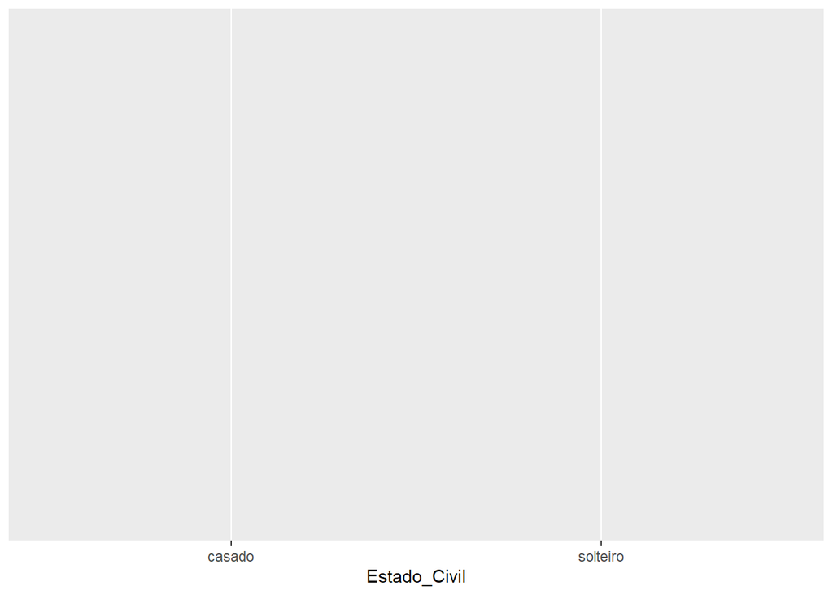

```r
graf = ggplot(milsa, aes(x = Estado_Civil))
graf
```

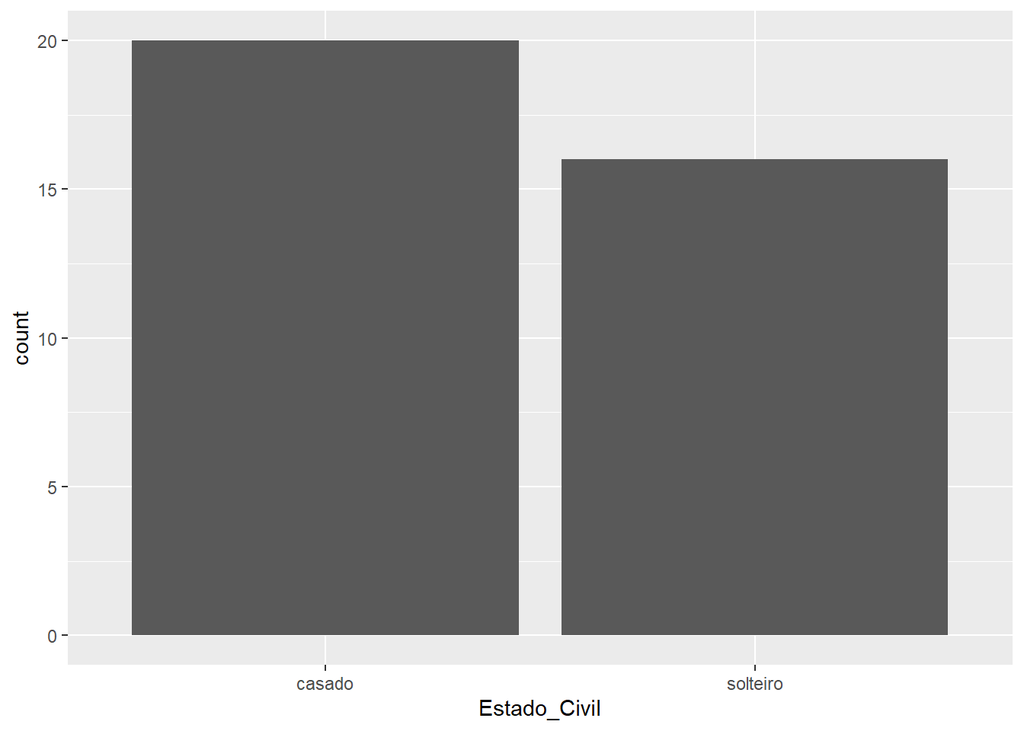

```r
graf = ggplot(milsa, aes(x = Estado_Civil)) + geom_bar()
graf
```

### 2.2.4 Moda

A moda de qualquer variável aleatória é definida como o valor mais frequente encontrado na amostra. No R não há uma função pronta para “calcular” a moda, pois ela pode ser obtida facilmente através do uso de funções básicas. Uma opção seria usar os comandos abaixo:

```r
civil_tb
```

```
##
##   casado solteiro
##       20       16
```

```r
names(civil_tb)[which.max(civil_tb)]
```

```
## [1] "casado"
```

## 2.3 Variável Qualitativa Ordinal

Para exemplificar como obter análises para uma variável qualitativa ordinal vamos selecionar a variável `Grau.de.Instrucao`.

### 2.3.1 Frequência absoluta

As tabelas de frequências são obtidas de forma semelhante à mostrada anteriormente.

```r
inst_tb <- table(milsa$Grau_Instrucao)
inst_tb
```

```
##
## ensino fundamental       ensino médio           superior
##                 12                 18                  6
```

### 2.3.2 Frequência relativa

```r
prop.table(inst_tb)
```

```
##
## ensino fundamental       ensino médio           superior
##          0.3333333          0.5000000          0.1666667
```

### 2.3.3 Gráfico de Frequência

Os gráficos de barras é adequado para representar esta variável. Vamos usar o `ggplot` para isso:

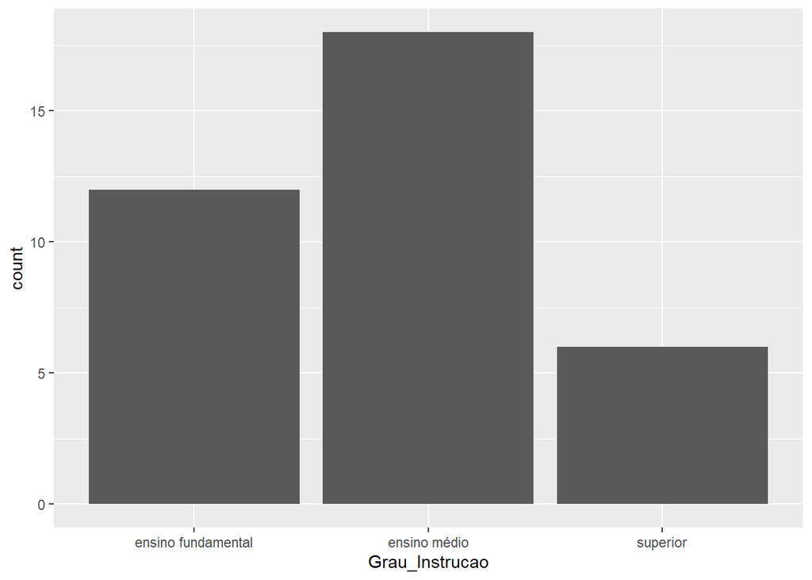

```r
graf2 = ggplot(milsa, aes(x = Grau_Instrucao)) + geom_bar()
graf2
```

E se a gente quiser ordenar nossas barras? **Vai ficar como atividade**

### 2.3.4 Moda

```r
names(inst_tb)[which.max(inst_tb)]
```

```
## [1] "ensino médio"
```

## 2.4 Variável Quantitativa Discreta

Vamos agora usar a variável `Filhos` (número de filhos) para ilustrar algumas análises que podem ser feitas com uma quantitativa discreta.

Frequências absolutas e relativas são obtidas como anteriormente. Também vamos calcular a frequência acumulada, onde a frequência em uma classe é a soma das frequências das classes anteriores. Para isso usamos a função `cumsum()`, que já faz a soma acumulada.

```r
filhos_tb <- table(milsa$Filhos)
filhos_tb
```

```
##
##  0  1  2  3  4  5
##  8 10 12  4  1  1
```

```r
filhos_tbr <- prop.table(filhos_tb)
filhos_tbr
```

```
##
##          0          1          2          3          4          5
## 0.22222222 0.27777778 0.33333333 0.11111111 0.02777778 0.02777778
```

### 2.4.1 Frequência Acumulada

```r
freq_rel_acum = cumsum(filhos_tbr)
freq_rel_acum
```

```
##         0         1         2         3         4         5
## 0.2222222 0.5000000 0.8333333 0.9444444 0.9722222 1.0000000
```

### 2.4.2 Gráfico de Frequência

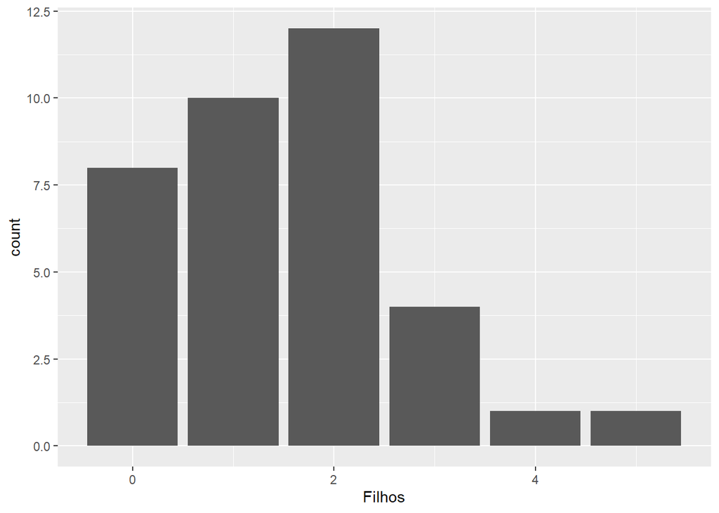

```r
ggplot(milsa, aes(x = Filhos)) + geom_bar()
```

### 2.4.3 Frequência relativa acumulada

```r
freq_rel_acum
```

```
##         0         1         2         3         4         5
## 0.2222222 0.5000000 0.8333333 0.9444444 0.9722222 1.0000000
```

```r
df = data.frame(x = names(freq_rel_acum), y = freq_rel_acum)
df
```

```
##   x         y
## 0 0 0.2222222
## 1 1 0.5000000
## 2 2 0.8333333
## 3 3 0.9444444
## 4 4 0.9722222
## 5 5 1.0000000
```

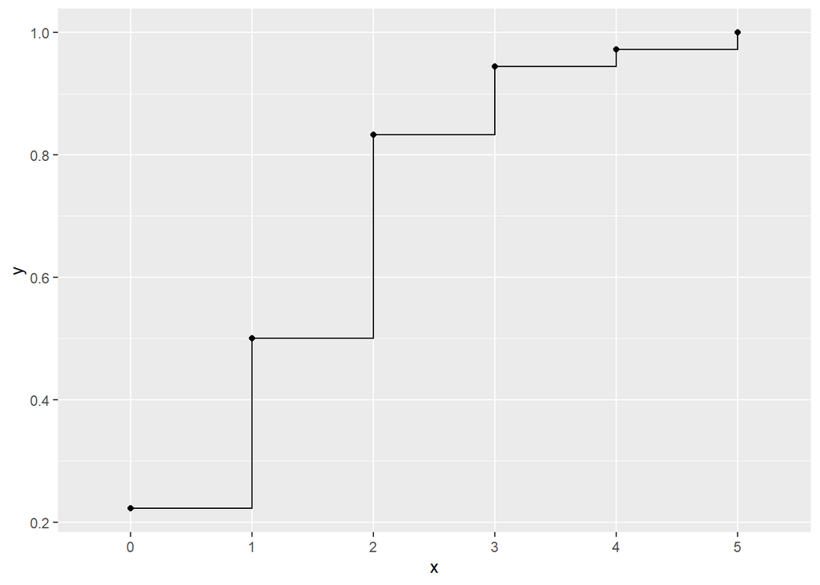

```r
ggplot(df, aes(x, y)) +
  geom_point() +
  geom_step(group = 1)
```

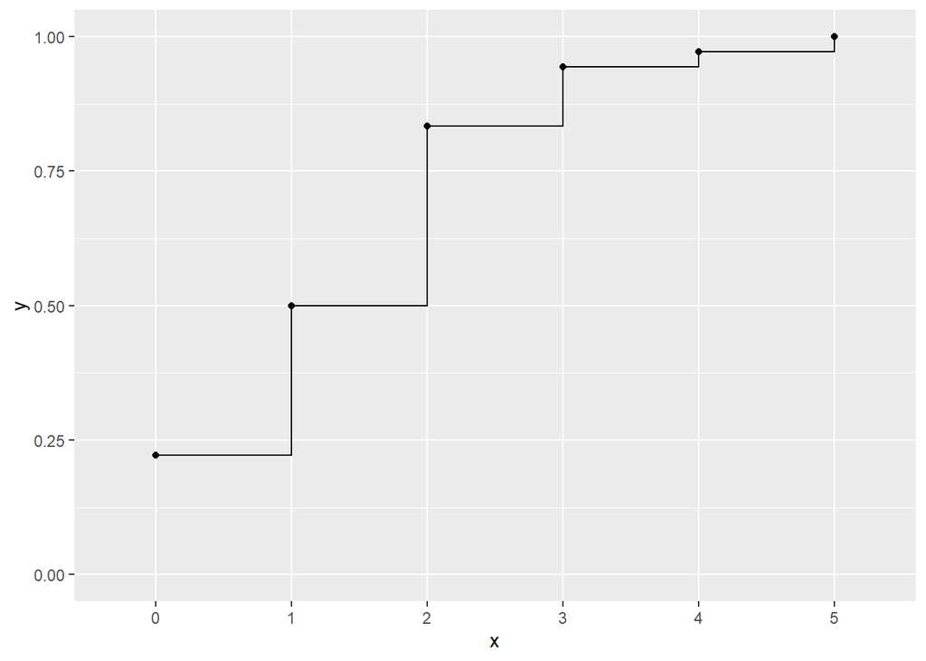

```r
ggplot(df, aes(x, y)) +
  geom_point() +
  geom_step(group = 1) +
  ylim(0, NA)
```

### 2.4.4 Medidas (moda, mediana e média)

```r
names(filhos_tb)[which.max(filhos_tb)]
```

```
## [1] "2"
```

```r
median(milsa$Filhos)
```

```
## [1] 1.5
```

```r
mean(milsa$Filhos)
```

```
## [1] 1.527778
```

### 2.4.5 Quartis

```r
quantile(milsa$Filhos)
```

```
##   0%  25%  50%  75% 100%
##  0.0  1.0  1.5  2.0  5.0
```

```r
sum(milsa$Filhos <= 1)
```

```
## [1] 18
```

### 2.4.6 Forma Prática

Podemos usar a função genérica `summary()` para resumir os dados de uma só vez:

```r
summary(milsa$Filhos)
```

```
##    Min. 1st Qu.  Median    Mean 3rd Qu.    Max.
##   0.000   1.000   1.500   1.528   2.000   5.000
```

### 2.4.7 Variância

```r
var(milsa$Filhos)
```

```
## [1] 1.456349
```

### 2.4.8 Desvio-padrão

```r
sd(milsa$Filhos)
```

```
## [1] 1.206793
```

## 2.5 Variável Quantitativa Contínua

Para concluir os exemplos para análise univariada vamos considerar a variável quantitativa contínua `Salario`.

O que podemos fazer de diferente é plotar um histograma e um boxplot:

### 2.5.1 Histograma

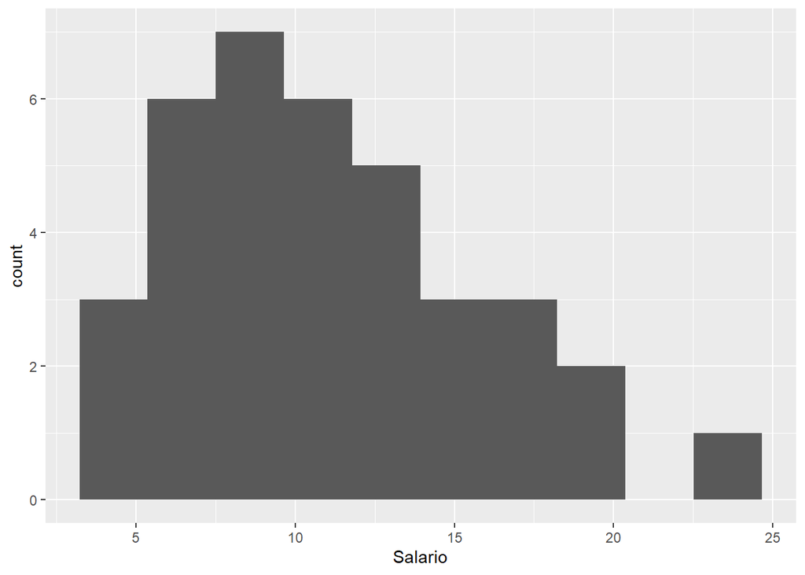

```r
ggplot(milsa, aes(x = Salario)) + geom_histogram(bins = 10)
```

### 2.5.2 BoxPlots

Os boxplots são úteis para revelar o centro, a dispersão e a distribuição dos dados, além de outliers.

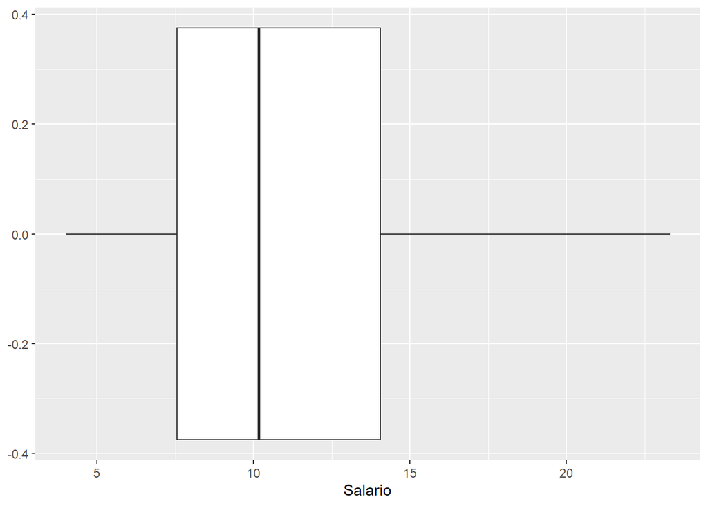

```r
ggplot(milsa, aes(x = Salario)) + geom_boxplot()
```

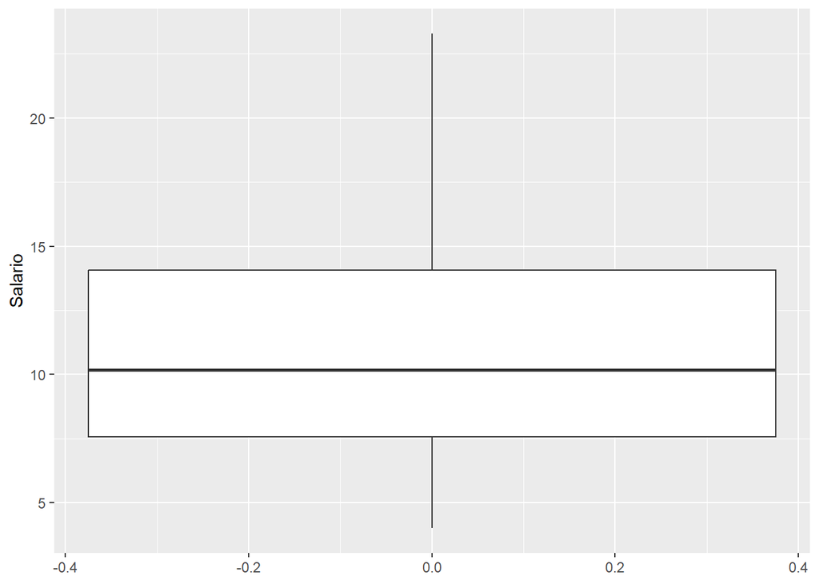

```r
ggplot(milsa, aes(y = Salario)) + geom_boxplot()
```